# Image Classification with PyTorch: Trying different image data augmentations when training a CNN

[Pablo Carballeira] (http://dymas.ii.uam.es/webvpu/gti/user/186/), Escuela Politecnica Superior, Universidad Autónoma de Madrid.

Parts of this code have been adapted from then work of Kevin McGuinness (http://www.eeng.dcu.ie/~mcguinne/), School of Electronic Engineering, Dublin City University, and the work of Ben Trevett (https://github.com/bentrevett), Heriot-Watt University

You can find documentation about working in Colab here (https://colab.research.google.com/notebooks/intro.ipynb)

In this lab assignment you will try different image data augmentation techniques to train a ResNet CNN on the CIFAR10 datastet. The objective of this assignment is that you try different data augmentation options and evaluate which is more efficient for your problem.

# Instructions

Go to the Section "Load data and define the image transformations" and modify it to try different image data augmentation techniques. You can also play with different values of the parameters of the transformations you utilize.

Each time you set a new set of transformations (training and validation), you have to run the whole notebook to evaluate its influence in the training process

# Import packages

Find the PyTorch docs at https://pytorch.org/docs/stable/index.html

Tutorials: https://pytorch.org/tutorials/

```python
import torch
import torch.nn as nn
import torch.nn.functional as F
import torch.optim as optim
from torch.optim.lr_scheduler import _LRScheduler
import torch.utils.data as data

import torchvision.transforms as transforms
import torchvision.datasets as datasets

from sklearn import decomposition
from sklearn import manifold
from sklearn.metrics import confusion_matrix
from sklearn.metrics import ConfusionMatrixDisplay
import matplotlib.pyplot as plt
import numpy as np

import copy
import random
import time
```

# Enable GPU acceleration

Open to the Edit menu and select *Notebook settings* and check that *GPU* is selected under hardware accelerator.

```python
# make sure to enable GPU acceleration!
device = torch.device('cuda' if torch.cuda.is_available() else 'cpu')
print(device)
```

```
cuda
```

We set the random seed so all of our experiments can be reproduced.

```python
SEED = 1234

random.seed(SEED)
np.random.seed(SEED)
torch.manual_seed(SEED)
torch.cuda.manual_seed(SEED)
torch.backends.cudnn.deterministic = True
```

# Dataset: CIFAR10

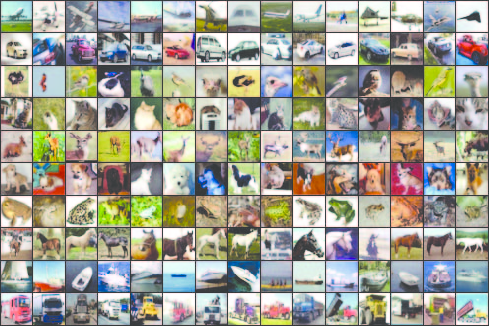

## Mean and standard deviation of the dataset

Here, we calculate the mean and standard deviation of our data so we can normalize it appropiately. CIFAR10 is made up of color images with three color channels (red, green and blue). To normalize the data we need to calculate the means and standard deviations for each of the color channels independently.

```python
# Download CIFAR10 from Google Drive link to avoid bandwith problems in official server
# Install gdown
!pip -q install gdown
# Create destination folder
!mkdir -p data

# Download using the Google Drive file ID
!gdown --id 1Kg6Hl3hJt75hUMF4XsOPxgAWdcWqIBIB -O data/cifar-10-python.zip
!unzip -o data/cifar-10-python.zip -d data/CIFAR10
```

```python
ROOT = "data/CIFAR10/cifar-10-python"

train_data = datasets.CIFAR10(root = ROOT,
                              train = True,
                              download = False)

# use the functions that are built in the dataset to compute the means and stds.
# Bear in mind that image pixels are in the [0,255] range, but they are converted to
# het [0,1] range when transformed to Tensor variables
means = train_data.data.mean(axis = (0,1,2)) / 255
stds = train_data.data.std(axis = (0,1,2)) / 255

print(f'Calculated means: {means}')
print(f'Calculated stds: {stds}')
```

```
Calculated means: [0.49139968 0.48215841 0.44653091]
Calculated stds: [0.24703223 0.24348513 0.26158784]
```

# CNN architecture: Residual Network

```python
class _Block(nn.Module):
    def __init__(self, kernel_dim, n_filters, in_channels, stride, padding):
        super(_Block, self).__init__()
        self._layer_one = nn.Conv2d(in_channels=in_channels, out_channels=n_filters,
                                  kernel_size=kernel_dim, stride=stride[0], padding=padding, bias=False)
        self._layer_two = nn.Conv2d(in_channels=n_filters, out_channels=n_filters,
                                  kernel_size=kernel_dim, stride=stride[1], padding=padding, bias=False)
        self.relu = nn.ReLU()
        self.bn1 = nn.BatchNorm2d(n_filters)
        self.bn2 = nn.BatchNorm2d(n_filters)
    def forward(self, X, shortcut = None):
        output = self._layer_one(X)
        output = self.bn1(output)
        output = self.relu(output)
        output = self._layer_two(output)
        output = self.bn2(output)
        output = self.relu(output)
        if isinstance(shortcut, torch.Tensor):
            return output + shortcut
        return output + X
class ResNet(nn.Module):
    def __init__(self, input_dim, n_classes):
        super(ResNet, self).__init__()
        self.n_classes = n_classes
        self.conv1 = nn.Conv2d(3, 64, 4, 2)
        self.block1 = _Block(5, 64, 64, (1,1), 2)
        self.block2 = _Block(5, 64, 64, (1,1), 2)
        self.block3 = _Block(5, 64, 64, (1,1), 2)
        self.transition1 = nn.Conv2d(64, 128, 1, 2, 0, bias=False)
        self.block4 = _Block(3, 128, 64, (2,1), 1)
        self.block5 = _Block(3, 128, 128, (1,1), 1)
        self.block6 = _Block(3, 128, 128, (1,1), 1)
        self.transition2 = nn.Conv2d(128, 256, 3, 2, 1, bias=False)
        self.block7 = _Block(3, 256, 128, (2,1), 1)
        self.block8 = _Block(3, 256, 256, (1,1), 1)
        self.block9 = _Block(3, 256, 256, (1,1), 1)
        self.transition3 = nn.Conv2d(256, 512, 3, 2, 1, bias=False)
        self.block10 = _Block(3, 512, 256, (2,1), 1)
        self.block11 = _Block(3, 512, 512, (1,1), 1)
        self.block12 = _Block(3, 512, 512, (1,1), 1)
        self.linear1 = nn.Linear(2048, n_classes)

    def forward(self, X):
        output = self.conv1(X)
        output = self.block1(output)
        output = self.block2(output)
        output = self.block3(output)
        shortcut1 = self.transition1(output)
        output = self.block4(output, shortcut1)
        output = self.block5(output)
        output = self.block6(output)
        shortcut2 = self.transition2(output)
        output = self.block7(output, shortcut2)
        output = self.block8(output)
        output = self.block9(output)
        shortcut3 = self.transition3(output)
        output = self.block10(output, shortcut3)
        output = self.block11(output)
        output = self.block12(output)
        output = output.view(-1, 2048)
        output = self.linear1(output)
        return output
```

```python
X = torch.ones((1,3,32,32))
model = ResNet(32, 10)
model.to(device)
X = X.to(device)
model(X)
```

```
tensor([[ 0.8200, -1.1248,  0.1818,  1.9149, -0.8585, -0.2306, -0.8057,  1.0634,
          0.1171, -0.8376]], device='cuda:0', grad_fn=<AddmmBackward0>)
```

# Load data and define the image transforms

```python
class Cutout:
    """Cutout (DeVries & Taylor, 2017): cuadrado de 16x16 a cero, centro aleatorio,
    recortado en los bordes. Se aplica sobre tensor ya normalizado."""
    def __init__(self, length=16):
        self.length = length

    def __call__(self, img):
        _, h, w = img.shape
        cy, cx = torch.randint(h, (1,)).item(), torch.randint(w, (1,)).item()
        y1, y2 = max(0, cy - self.length // 2), min(h, cy + self.length // 2)
        x1, x2 = max(0, cx - self.length // 2), min(w, cx + self.length // 2)
        img = img.clone()
        img[:, y1:y2, x1:x2] = 0.0
        return img

train_transform = transforms.Compose([
    transforms.RandomCrop(32, padding=4),
    transforms.RandomHorizontalFlip(),
    transforms.AutoAugment(transforms.AutoAugmentPolicy.CIFAR10),
    transforms.ToTensor(),
    transforms.Normalize([0.49139968, 0.48215841, 0.44653091], [0.24703223, 0.24348513, 0.26158784]),
    Cutout(16),
])

valid_transform = transforms.Compose([
    transforms.ToTensor(),
    transforms.Normalize([0.49139968, 0.48215841, 0.44653091], [0.24703223, 0.24348513, 0.26158784])
    ])
```

```python
from torch.utils.data import DataLoader
from torchvision.datasets import CIFAR10

classes = ('plane', 'car', 'bird', 'cat',
           'deer', 'dog', 'frog', 'horse', 'ship', 'truck')

train_set = CIFAR10(root="data/CIFAR10/cifar-10-python", train=np.true_divide, download = False, transform=train_transform)
valid_set = CIFAR10(root="data/CIFAR10/cifar-10-python", train=False, download = False, transform=valid_transform)

BATCH_SIZE = 256

# Create training and validation loaders
train_loader = DataLoader(train_set, batch_size=BATCH_SIZE, num_workers=2, shuffle=True)
valid_loader = DataLoader(valid_set, batch_size=BATCH_SIZE, num_workers=2, shuffle=True)
```

```python
print(f'train set is', ' x '.join(str(x) for x in train_set.data.shape))
print(f'valid set is', ' x '.join(str(x) for x in valid_set.data.shape))
```

```
train set is 50000 x 32 x 32 x 3
valid set is 10000 x 32 x 32 x 3
```

# Training the Model

## Set up training parameters

```python
loss_fn = nn.CrossEntropyLoss()
LR = 0.001
optim = torch.optim.Adam(model.parameters(), lr = LR, weight_decay=0.0001)
epoch_loss_DA = []
val_loss_DA = []
acc_DA = []
train_time = 0

EPOCHS = 25
```

## Train and evaluate

```python
for i in range(EPOCHS):
    start_time = time.time()
    ep = 0
    model.train()
    for X_b, y_b in train_loader:
        optim.zero_grad()
        X_b = X_b.to(device)
        y_b = y_b.to(device)
        output = model(X_b)
        loss = loss_fn(output, y_b)
        loss.backward()
        ep += loss.item()
        optim.step()
    epoch_loss_DA.append(ep*BATCH_SIZE/50000)
    train_time += time.time() - start_time

    correct = 0
    total = 0
    val = 0
    model.eval()

    for X_b, y_b in valid_loader:
        X_b = X_b.to(device)
        y_b = y_b.to(device)
        output = model(X_b)
        loss = loss_fn(output, y_b)
        val += loss.item()
        probs = torch.functional.F.softmax(output, 1)
        label = torch.argmax(probs, dim=1)
        correct += torch.sum(label == y_b).item()
        total += y_b.shape[0]
    val_loss_DA.append(val*BATCH_SIZE/10000)
    acc_DA.append(round(correct/total,2))

    print(f'[{i:03d}] train loss: {ep*BATCH_SIZE/50000:04f}  '
              f'val loss: {val*BATCH_SIZE/10000:04f}  '
              f'val acc: {correct/10000*100:.4f}%')

print("--- %s seconds ---", train_time)
```

```
[000] train loss: 2.640662  val loss: 2.302433  val acc: 37.8900%
[001] train loss: 2.005382  val loss: 2.024024  val acc: 38.9000%
[002] train loss: 1.862063  val loss: 1.530590  val acc: 45.3800%
[003] train loss: 1.770951  val loss: 1.472393  val acc: 49.1400%
[004] train loss: 1.658640  val loss: 1.347169  val acc: 52.4000%
[005] train loss: 1.578233  val loss: 1.203664  val acc: 58.4500%
[006] train loss: 1.494218  val loss: 1.278803  val acc: 60.5000%
[007] train loss: 1.417094  val loss: 1.281043  val acc: 61.6700%
[008] train loss: 1.364070  val loss: 1.202657  val acc: 63.2800%
[009] train loss: 1.311493  val loss: 0.993469  val acc: 66.9100%
[010] train loss: 1.272470  val loss: 0.990530  val acc: 66.9900%
[011] train loss: 1.233265  val loss: 0.892430  val acc: 69.2000%
[012] train loss: 1.204368  val loss: 0.882342  val acc: 71.4000%
[013] train loss: 1.170642  val loss: 0.823998  val acc: 72.5900%
[014] train loss: 1.143897  val loss: 0.755336  val acc: 74.6700%
[015] train loss: 1.116850  val loss: 0.734646  val acc: 76.1700%
[016] train loss: 1.093014  val loss: 0.759861  val acc: 75.0800%
[017] train loss: 1.070283  val loss: 0.710361  val acc: 76.4200%
[018] train loss: 1.060046  val loss: 0.755602  val acc: 75.4600%
[019] train loss: 1.047139  val loss: 0.696672  val acc: 76.6600%
[020] train loss: 1.016460  val loss: 0.715807  val acc: 76.2800%
[021] train loss: 1.009940  val loss: 0.612790  val acc: 79.2500%
[022] train loss: 0.993079  val loss: 0.636478  val acc: 78.9400%
[023] train loss: 0.978858  val loss: 0.598440  val acc: 80.0100%
[024] train loss: 0.958397  val loss: 0.617856  val acc: 79.9000%
--- %s seconds --- 1079.1058373451233
```

## Plot graphs

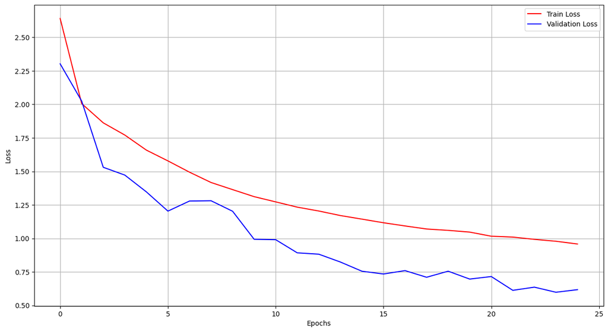

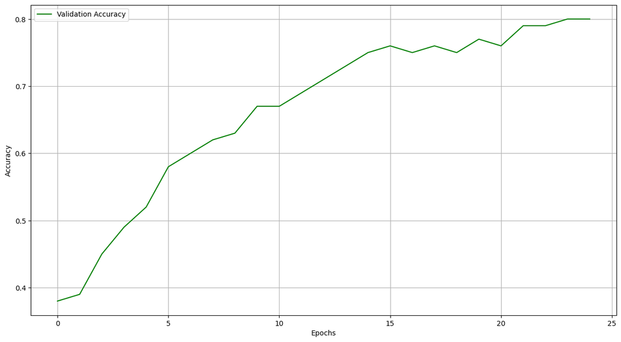

```python
fig, ax = plt.subplots(figsize=(15, 8))
plt.plot(range(EPOCHS), epoch_loss_DA , color='r')
plt.plot(range(EPOCHS), val_loss_DA, color='b')
plt.legend(["Train Loss", "Validation Loss"])
plt.xlabel("Epochs")
plt.ylabel("Loss")
ax.grid(True)

fig, ax = plt.subplots(figsize=(15, 8))
plt.plot(range(EPOCHS), acc_DA , color='g')
plt.legend(["Validation Accuracy"])
plt.xlabel("Epochs")
plt.ylabel("Accuracy")
ax.grid(True)
```

The code below saves the notebook and exports it to HTML. To avoid problems, check the result and re-run the saving and exporting sections more than once before completing the lab assignment

```python
from google.colab import drive

# Mount Google Drive
drive.mount('/content/drive')
```

```python
# indicate the path to your notebok here
# EXAMPLE: ipynb_file = Path("/content/drive/MyDrive/Colab Notebooks/[UAM-VisDL- NBs]/[UAM-VAAP] Image Data Augmentation (2).ipynb")
# ???
from pathlib import Path

ipynb_file = Path(
    "/content/drive/MyDrive/VISION-ARTIFICIAL/Pr2/[UAM-VAAP]ImageDataAugmentation2.ipynb"
)
```

```python
# @title
from IPython.display import Javascript, display
import time

display(Javascript("""
async function saveNotebook() {
    await google.colab.notebook.saveCheckpoint();
}
saveNotebook();
"""))

time.sleep(10)
```

```python
# Export the currently running Google Colab notebook to HTML
# and save it next to the notebook in Google Drive.

from nbconvert import HTMLExporter
import nbformat

html_file = ipynb_file.with_suffix(".html")

with open(ipynb_file, "r", encoding="utf-8") as f:
    notebook = nbformat.read(f, as_version=4)

html_exporter = HTMLExporter()
body, _ = html_exporter.from_notebook_node(notebook)

with open(html_file, "w", encoding="utf-8") as f:
    f.write(body)

print(f"✅ Exported to {html_file}")
```